# Residential Population Density and Daily Travel Distance in the United States A Cross-Sectional Regression Analysis of Nonlinearity and Heterogeneity

3281675Z

2026-11-08

```
## [1] "/Users/pippin/Documents/Code/URBAN5127_NHTS/R"
```

Residential Population Density and Mean Trip Distance among Adult Travellers in the United States: Evidence from the 2022 NextGen NHTS

# Inroduction

The relationship between the built environment and travel behaviour has long been an important topic in urban and transport planning. Previous research suggests that characteristics of the built environment, including population density, land-use diversity and urban design, are associated with how people travel (Cervero and Kockelman, 1997). However, the strength of these relationships remains debated. Ewing and Cervero (2010) found that population density was only weakly associated with travel behaviour after accounting for other built-environment characteristics. Similarly, Stevens (2017) concluded that compact development was associated with reduced driving, but the estimated effect was relatively small. These findings suggest that residential density alone may not fully explain differences in travel behaviour, making it important to consider individual and household characteristics.

In this paper, we will utilise data from the 2022 NextGen National Household Travel Survey (NHTS) to examine the relationship between residential population density and mean trip distance among adult travelers in the United States. We will test whether this relationship remains after controlling for individual and household characteristics, such as age, employment status, household size, and survey day. We will also investigate whether the relationship varies according to household vehicle ownership.

# Data

The following variables are selected from the dataset for the analysis and are defined in Table 1.

Table 1. Variable Names and Definitions

| Variable | Field_Name | Description |
| --- | --- | --- |
| Mean trip distance | mean_trip_miles | Mean distance per recorded trip for each adult traveller on their assigned travel day, measured in miles. |
| Residential population density | density_band | Census tract population density at the respondent’s residential location, classified into eight categories (HTPPOPDN). |
| Aggregated population density | density_group | Residential population density reclassified into four categories for the interaction model (M3). |
| Age | age | Age of the respondent in years. |
| Age squared | age_squared | Squared centred age term used to account for potential nonlinear associations between age and mean trip distance. |
| Employment status | worker | Employment status of the respondent, classified as worker or non-worker. |
| Household size | hh_size | Number of people living in the respondent’s household. |
| Survey day | travday | Day of the week on which the respondent’s travel activities were recorded. |
| Household vehicle ownership | car_group | Number of vehicles available to the household, classified into zero, one, and two or more vehicles. |
| Population density × Vehicle ownership | density_car_interaction | Interaction between aggregated residential population density and household vehicle ownership, used to examine whether their associations with mean trip distance vary across groups. |

Note: Mean trip distance is the dependent variable. Residential population density is the main independent variable. The remaining demographic and household characteristics are included as controls or extensions across M0–M3. The interaction term is constructed within M3 rather than being an original NHTS variable.

# Data Cleaning

The data were obtained from the National Household Travel Survey (NHTS), comprising 16,997 person records and 31,074 trip records. Trip records were grouped by household and individual identifiers to calculate the mean trip distance for each person. The resulting summaries were then merged with the person-level dataset. Checks found no duplicate identifiers, unmatched trip records, or inconsistencies between reported and recorded trip counts.

We filter the data to include only relevant observations and to exclude potentially erroneous values. The data are filtered based on the following set of rules:

1. Include only adults aged 18 years and above, leaving 14,423 observations.
2. Include only individuals with at least one recorded trip, reducing the sample to 9,100 adult travellers.
3. Exclude individuals with missing, negative, or non-finite trip distances, leaving 9,088 observations with complete trip distance records.
4. Include only observations with valid residential population density codes (HTPPOPDN: 01–08), leaving 9,052 observations.
5. Include only observations with valid employment status codes (WORKER: 01 or 02).
6. Exclude observations with zero or negative household size.
7. Exclude observations with negative or missing household vehicle ownership values.
8. Include only observations with valid survey day codes (TRAVDAY: 01–07).
9. Exclude observations with missing, non-finite, or non-positive person-level survey weights (WTPERFIN).

The final sample consists of **9,052 adult travellers**. No additional observations were excluded after applying the restrictions on the core control variables and survey weights. This dataset is used for the subsequent descriptive statistics and regression analysis.

### Code of Data Cleaning

##### 1. Read the raw data files, identify the field types

Raw Data Overview

| Dataset | Rows | Columns |
| --- | --- | --- |
| person | 16997 | 153 |
| trip | 31074 | 102 |

##### 2. Check for missing, negative, and zero values in trip distances

```
##     Min.  1st Qu.   Median     Mean  3rd Qu.     Max.
##   -9.000    1.759    4.280   13.965   10.422 4859.477
```

Summary of Trip Distances

| total_trips | missing_value | negative_distance | zero_distance | valid_distance |
| --- | --- | --- | --- | --- |
| 31074 | 0 | 14 | 99 | 31060 |

#### 3. Group Trip by Household and Person

##### 3.1. Check for duplicates and unmatched records

Data Quality Checks

| Check | Result |
| --- | --- |
| Duplicate person keys | 0 |
| Duplicate trip keys | 0 |
| Unmatched trip records | 0 |

##### 3.2. Count the number of trips for each individual

```
## Number of Individuals with Trip Records: 10592
```

##### 3.3. Summarise trip distances for each individual

```
## Rows: 10,592
## Columns: 5
## $ HOUSEID             <chr> "9000013002", "9000013002", "9000013002", "9000013…
## $ PERSONID            <chr> "01", "02", "04", "01", "02", "01", "01", "02", "0…
## $ n_trips             <int> 2, 3, 2, 3, 3, 2, 2, 2, 1, 2, 2, 5, 3, 2, 2, 2, 3,…
## $ all_distances_valid <lgl> TRUE, TRUE, TRUE, TRUE, TRUE, TRUE, TRUE, TRUE, TR…
## $ mean_trip_miles     <dbl> 3.9024239, 11.9747255, 3.9024239, 3.6444997, 3.644…
```

Summary of Trip Distances by Individual

| n_persons | invalid_persons | valid_persons | zero_mean |
| --- | --- | --- | --- |
| 10592 | 14 | 10578 | 53 |

##### 4. Associate trip summaries with person-level data

```
## The number of rows in person_day 16997 matches the number of rows in person 16997 .
```

First 10 Rows of Person-Day Dataset with Selected Variables

| HOUSEID | PERSONID | R_AGE | HTPPOPDN | n_trips | mean_trip_miles |
| --- | --- | --- | --- | --- | --- |
| 9000013002 | 01 | 39 | 04 | 2 | 3.9024239 |
| 9000013002 | 02 | 42 | 04 | 3 | 11.9747255 |
| 9000013002 | 03 | 8 | 04 | NA | NA |
| 9000013002 | 04 | 5 | 04 | 2 | 3.9024239 |
| 9000013016 | 01 | 32 | 07 | 3 | 3.6444997 |
| 9000013016 | 02 | 41 | 07 | 3 | 3.6444997 |
| 9000013026 | 01 | 44 | 07 | NA | NA |
| 9000013039 | 01 | 38 | 07 | 2 | 0.6351771 |
| 9000013039 | 02 | 37 | 07 | NA | NA |
| 9000013039 | 03 | 12 | 07 | NA | NA |

Summary of Individuals with and without Recorded Trips

| total_persons | Mismatch | with_trips | without_trips |
| --- | --- | --- | --- |
| 16997 | 0 | 10592 | 6405 |

##### 5. Filter for adults aged 18 and above

```
## Preview summary of the 'age' variable:
```

```
##    Min. 1st Qu.  Median    Mean 3rd Qu.    Max.
##    5.00   28.00   48.00   45.92   65.00   92.00
```

Summary of Adult Individuals (Age 18 and Above)

| total_adults | missing_age | under_18 | valid_adults |
| --- | --- | --- | --- |
| 16997 | 0 | 2574 | 14423 |

##### 6. Filter for adults with at least one recorded trip

```
## # A tibble: 2 × 2
##   has_trip     n
##   <lgl>    <int>
## 1 FALSE     5323
## 2 TRUE      9100
```

```
## 9100 adult travellers with at least one recorded trip.
```

##### 7. Check for invalid trip distances among adult travellers

```
## # A tibble: 2 × 2
##   all_distances_valid     n
##   <lgl>               <int>
## 1 FALSE                  12
## 2 TRUE                 9088
```

```
## 9088 adult travellers with complete trip distance records.
```

##### 8. Filter for valid residential population density codes

```
## # A tibble: 9 × 2
##   HTPPOPDN     n
##   <chr>    <int>
## 1 06        1920
## 2 05        1916
## 3 02        1330
## 4 04        1272
## 5 01        1139
## 6 03         772
## 7 07         438
## 8 08         265
## 9 -9          36
```

```
## Valid residential population density codes: 01, 02, 03, 04, 05, 06, 07, 08
```

```
## 9052 adult travellers with valid residential population density codes.
```

##### 9. Check for invalid values in core control variables

```
## 9052 adult travellers with valid core control variables.
```

Sample Selection and Data Integration

| Sample | Unit | Observations |
| --- | --- | --- |
| Raw person records | Person | 16,997 |
| Raw trip records | Trip | 31,074 |
| Merged person-level dataset | Person | 16,997 |
| Adults aged 18 or older | Person | 14,423 |
| Adults with at least one recorded trip | Person | 9,100 |
| Adults with complete trip distance records | Person | 9,088 |
| Adults with valid population density codes | Person | 9,052 |
| Final analysis sample | Person | 9,052 |

# Summary Statistics

Table 2: Summary Statistics by Residential Population Density

| Variable | D1 | D2 | D3 | D4 | D5 | D6 | D7 | D8 | Total |
| --- | --- | --- | --- | --- | --- | --- | --- | --- | --- |
| N | 1,139 | 1,330 | 772 | 1,272 | 1,916 | 1,920 | 438 | 265 | 9,052 |
| **Mean trip distance (miles)** |  |  |  |  |  |  |  |  |  |
| Mean (SD) | 21.82 (54.38) | 23.28 (86.05) | 16.27 (43.22) | 20.54 (72.07) | 17.17 (73.05) | 15.39 (82.31) | 11.76 (50.14) | 11.32 (37.32) | 18.24 (71.32) |
| Median (IQR) | 9.57 (14.55) | 7.44 (12.59) | 5.87 (11.17) | 5.94 (9.43) | 5.05 (9.56) | 4.27 (7.47) | 3.84 (6.68) | 2.07 (4.34) | 5.57 (10.34) |
| Range | 0.00–822.61 | 0.00–1502.06 | 0.00–446.32 | 0.00–798.24 | 0.00–1375.78 | 0.00–2435.91 | 0.00–636.63 | 0.09–343.13 | 0.00–2435.91 |
| **Age (years)** |  |  |  |  |  |  |  |  |  |
| Mean (SD) | 53.66 (16.37) | 53.69 (16.82) | 52.45 (16.73) | 52.85 (17.63) | 51.74 (16.98) | 50.40 (17.23) | 46.34 (16.71) | 45.76 (17.28) | 51.76 (17.12) |
| **Household size** |  |  |  |  |  |  |  |  |  |
| Mean (SD) | 2.55 (1.23) | 2.69 (1.41) | 2.68 (1.35) | 2.57 (1.27) | 2.58 (1.29) | 2.58 (1.37) | 2.35 (1.29) | 2.04 (1.05) | 2.57 (1.32) |
| **Employment status, n (%)** |  |  |  |  |  |  |  |  |  |
| Worker | 675 (59.3%) | 782 (58.8%) | 481 (62.3%) | 763 (60.0%) | 1,209 (63.1%) | 1,194 (62.2%) | 329 (75.1%) | 186 (70.2%) | 5,619 (62.1%) |
| Non-worker | 464 (40.7%) | 548 (41.2%) | 291 (37.7%) | 509 (40.0%) | 707 (36.9%) | 726 (37.8%) | 109 (24.9%) | 79 (29.8%) | 3,433 (37.9%) |
| **Vehicle ownership, n (%)** |  |  |  |  |  |  |  |  |  |
| 0 vehicles | 6 (0.5%) | 16 (1.2%) | 10 (1.3%) | 18 (1.4%) | 40 (2.1%) | 76 (4.0%) | 27 (6.2%) | 93 (35.1%) | 286 (3.2%) |
| 1 vehicle | 189 (16.6%) | 241 (18.1%) | 168 (21.8%) | 259 (20.4%) | 436 (22.8%) | 573 (29.8%) | 208 (47.5%) | 124 (46.8%) | 2,198 (24.3%) |
| 2+ vehicles | 944 (82.9%) | 1,073 (80.7%) | 594 (76.9%) | 995 (78.2%) | 1,440 (75.2%) | 1,271 (66.2%) | 203 (46.3%) | 48 (18.1%) | 6,568 (72.6%) |

# Data visualization

```
## # A tibble: 8 × 2
##   density_band     n
##   <fct>        <int>
## 1 D1            1139
## 2 D2            1330
## 3 D3             772
## 4 D4            1272
## 5 D5            1916
## 6 D6            1920
## 7 D7             438
## 8 D8             265
```

#### Figure 1. Histogram of Mean Trip Distance

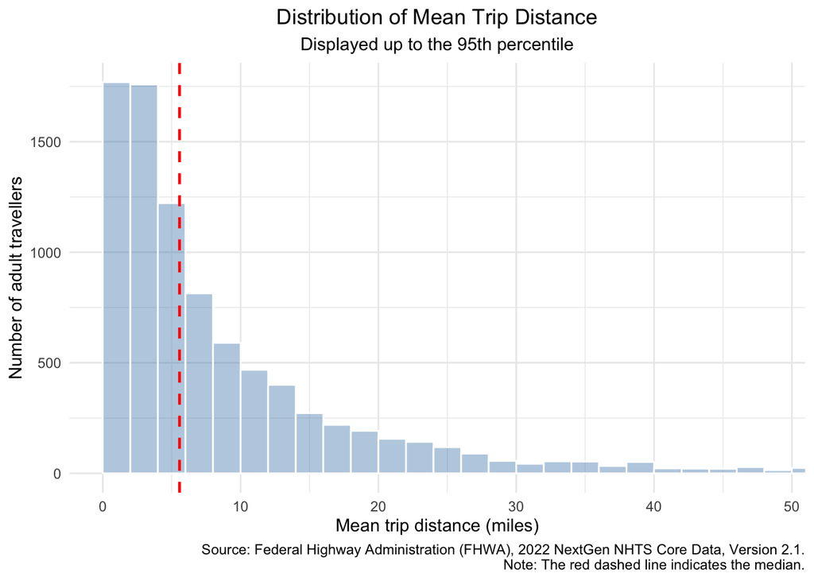

**Figure 1** shows a strongly right-skewed distribution of mean trip distance, with most observations concentrated at shorter distances. The frequency declines substantially as distance increases. The median, indicated by the dashed line, lies within the lower end of the distribution. This suggests that a relatively small number of long-distance observations may influence the mean.

#### Figure 2. Density Plot of Mean Trip Distance

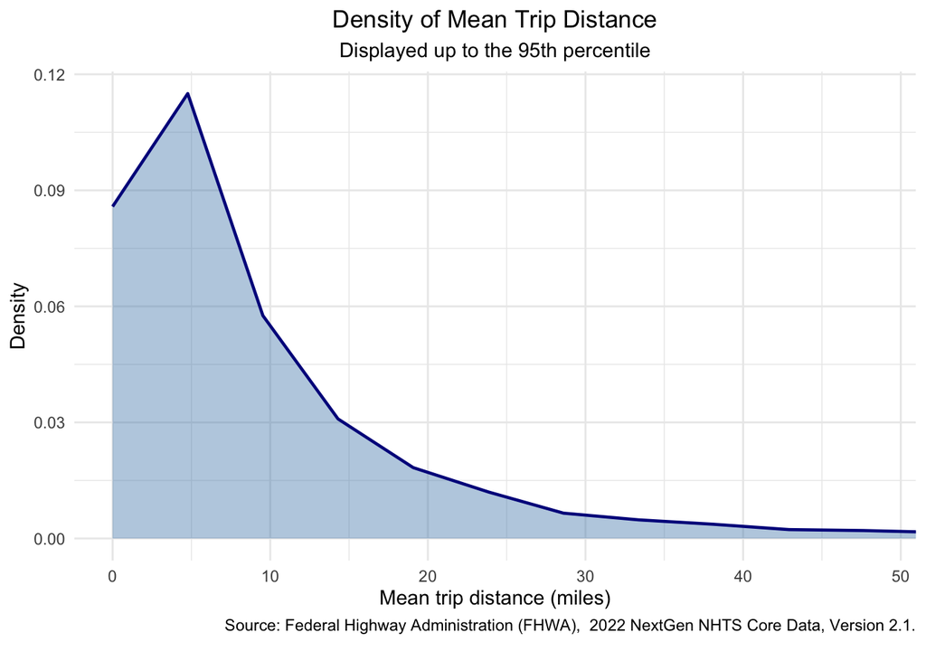

**Figure 2** further illustrates the right-skewed distribution of mean trip distance. The density is highest at relatively short distances and declines rapidly as distance increases, with a long right tail. This indicates substantial variation in travel distances and suggests that the distribution should be considered when specifying and diagnosing subsequent regression models.

#### Figure 3. Faceted Density Plots of Mean Trip Distance by Residential Population Density

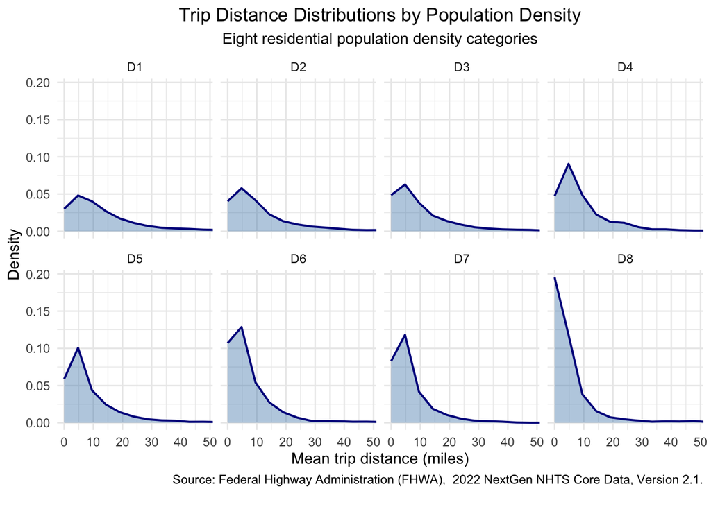

**Figure 3** compares trip distance distributions across eight residential population density categories. Higher-density groups, particularly D8, show a greater concentration of observations at shorter distances. Lower-density groups generally display more dispersed distributions. These differences suggest an association between residential population density and trip distance, although other individual and household characteristics may contribute to the observed patterns.

#### Figure 4. Boxplot of Mean Trip Distance by Residential Population Density

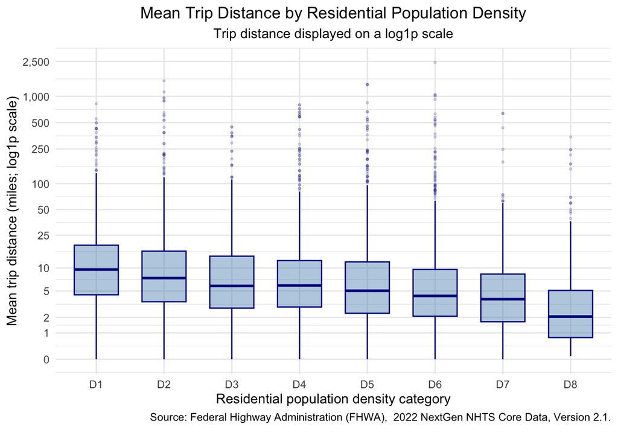

**Figure 4** shows that median trip distance generally decreases as residential population density increases. Lower-density categories have higher medians and wider interquartile ranges, while higher-density categories tend to have shorter trips. However, considerable overlap and numerous outliers remain across groups, indicating substantial individual variation within each density category.

#### Figure 5A. Distribution of Sample Size by Residential Population Density

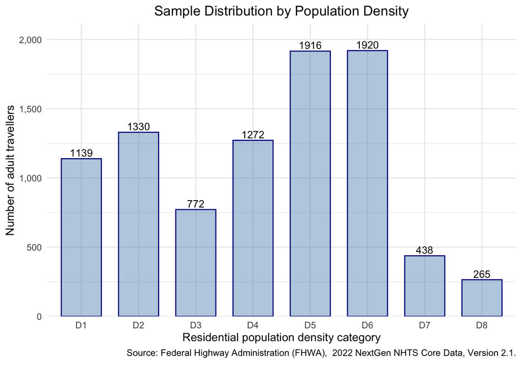

**Figure 5A** shows an uneven distribution of respondents across the eight population density categories. D5 and D6 contain the largest samples, with 1,916 and 1,920 individuals respectively, while D8 has only 265 observations. These differences highlight potential imbalances in statistical precision across density groups, particularly in subsequent interaction analyses.

#### Figure 5B. Mean and Median Trip Distance by Residential Population Density

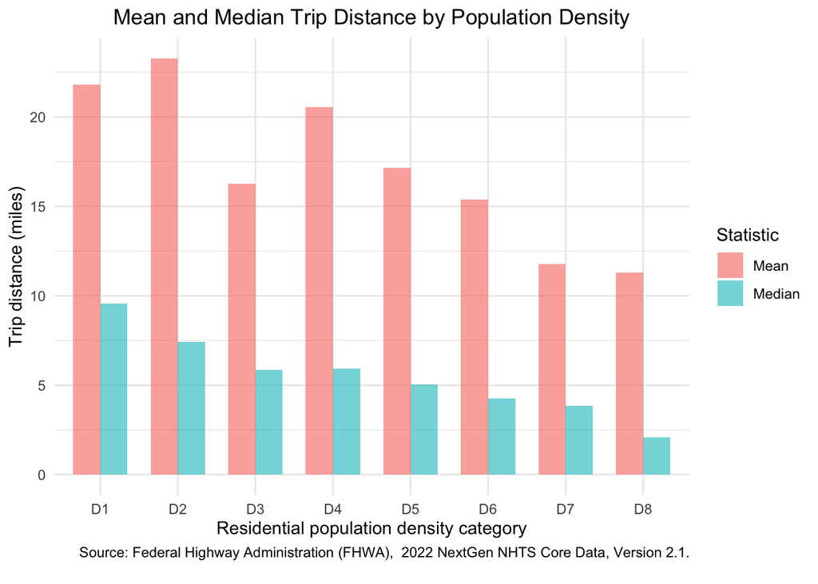

**Figure 5B** shows that mean trip distance generally declines across higher population density categories, although the pattern is not strictly monotonic. Mean distances exceed medians in every group, reflecting the influence of longer trips. D2 has the highest mean distance, while D8 has the lowest, suggesting an overall negative association between density and trip distance.

#### Figure 6. Scatterplot of Age and Mean Trip Distance

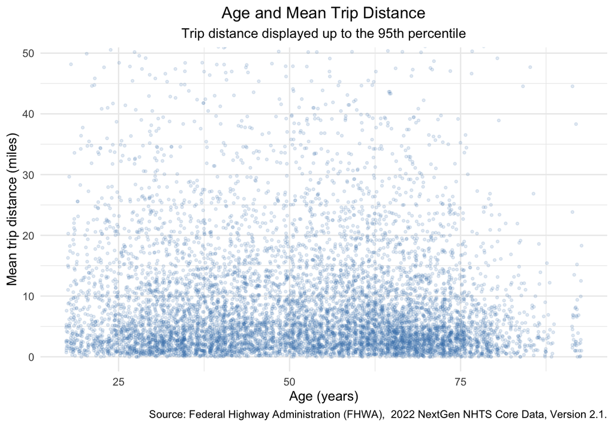

**Figure 6** illustrates substantial variation in mean trip distance across different ages. Most observations are concentrated at relatively short distances, while longer trips occur throughout much of the age range. No strong linear relationship is immediately apparent. This suggests that age alone explains limited variation in trip distance and warrants further examination using regression models.

#### Figure 7. Jitter Plot of Mean Trip Distance by Household Vehicle Ownership

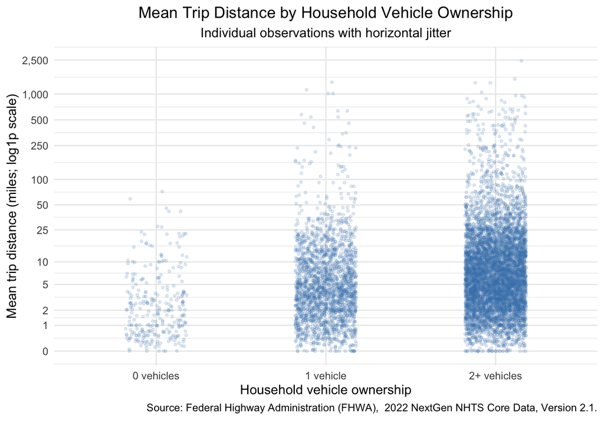

**Figure 7** illustrates differences in trip distance across household vehicle ownership categories. Respondents from households without vehicles are generally concentrated at shorter distances, whereas those with two or more vehicles display a wider range of travel distances. The groups also differ considerably in sample size, highlighting the importance of examining vehicle ownership in subsequent models.

#### Figure 8. Linear Regression Fit between Age and Mean Trip Distance

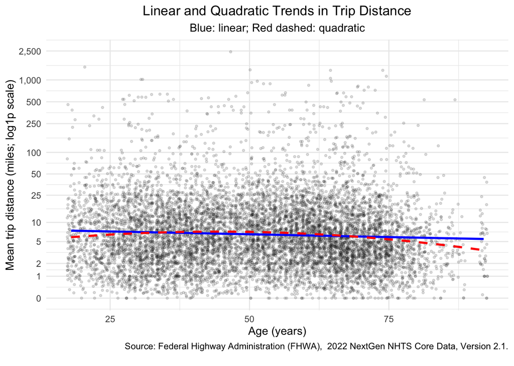

**Figure 8** compares linear and quadratic trends between age and mean trip distance. Both fitted lines suggest a relatively weak relationship, although the quadratic specification indicates some curvature, particularly at older ages. The substantial dispersion of observations around both curves suggests that age alone has limited explanatory power and supports including additional control variables.

#### Figure 9. Boxplot of Mean Trip Distance by Household Vehicle Ownership

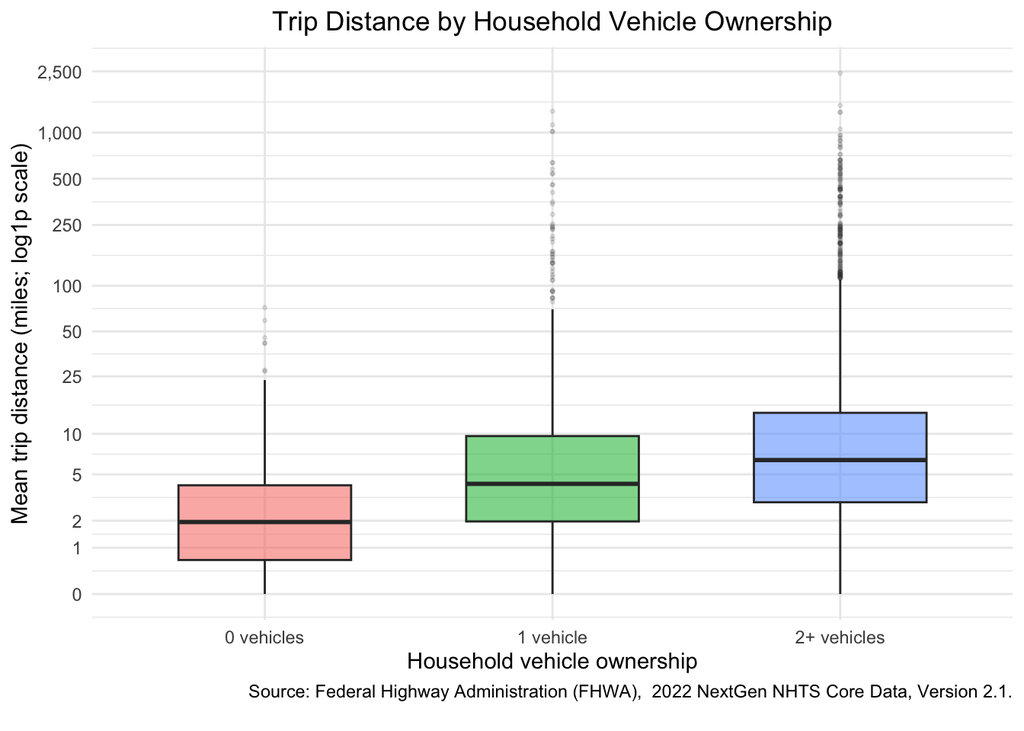

**Figure 9** shows differences in mean trip distance across vehicle ownership categories. Households without vehicles have the lowest median trip distance, while households with two or more vehicles have the highest. The interquartile ranges also increase with vehicle ownership. However, overlapping distributions and numerous outliers indicate considerable variation within each group.

#### Figure 10. Density Plots of Mean Trip Distance by Household Vehicle Ownership

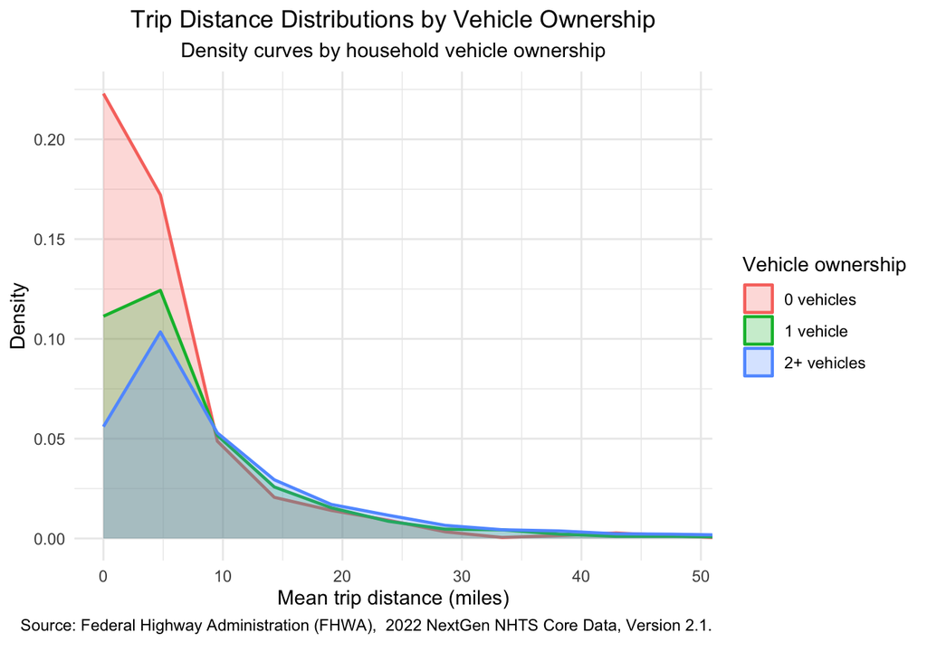

**Figure 10** compares trip distance distributions across three vehicle ownership categories. Households without vehicles show a pronounced concentration at very short distances. Households with one or more vehicles exhibit distributions extending further towards longer trips. Nevertheless, all three distributions remain right-skewed, and substantial overlap suggests that vehicle ownership alone cannot explain travel distance differences.

#### Figure 11. Boxplots of Mean Trip Distance by Residential Population Density and Household Vehicle Ownership

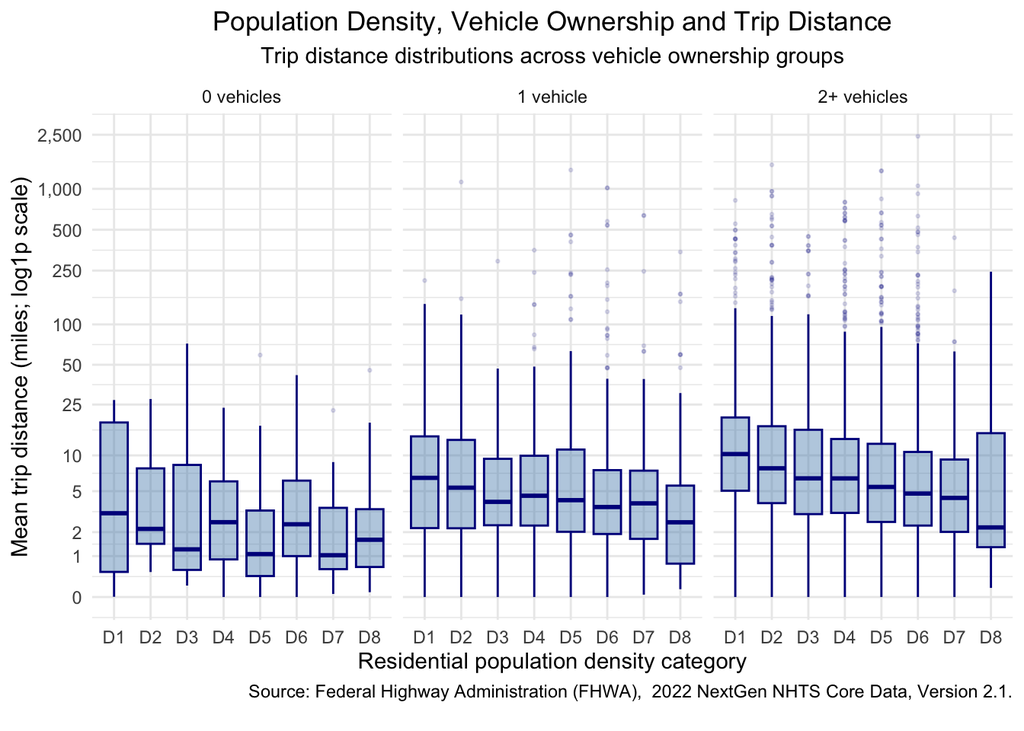

**Figure 11** examines trip distance distributions across population density categories within each vehicle ownership group. Trip distances generally appear shorter in higher-density areas, although the patterns vary between ownership categories. Considerable overlap remains, and some density–vehicle combinations contain relatively few observations. These differences motivate further investigation using interaction terms in the regression models.

# Reflection

This preliminary analysis has strengthened my understanding of how survey data can be cleaned, combined, and explored in R. The descriptive results suggest differences in trip distance across density and vehicle ownership groups, but do not establish causality. The highly skewed outcome and uneven group sizes highlight important analytical limitations. In the next stage, I will use multivariable regression and sensitivity checks to assess whether these associations persist after adjustment.

# References

Cervero, R. and Kockelman, K. (1997) ‘Travel demand and the 3Ds: Density, diversity, and design’, *Transportation Research Part D: Transport and Environment*, 2(3), pp. 199–219. https://doi.org/10.1016/S1361-9209(97)00009-6

Ewing, R. and Cervero, R. (2010) ‘Travel and the built environment: A meta-analysis’, *Journal of the American Planning Association*, 76(3), pp. 265–294. https://doi.org/10.1080/01944361003766766

Stevens, M.R. (2017) ‘Does compact development make people drive less?’, *Journal of the American Planning Association*, 83(1), pp. 7–18. https://doi.org/10.1080/01944363.2016.1240044

Federal Highway Administration (2022) *2022 National Household Travel Survey*. Washington, DC: U.S. Department of Transportation. Available at: https://nhts.ornl.gov/ (Accessed: 8 November 2026).